# REFERENTIAL INTEGRITY CONSTRAINTS

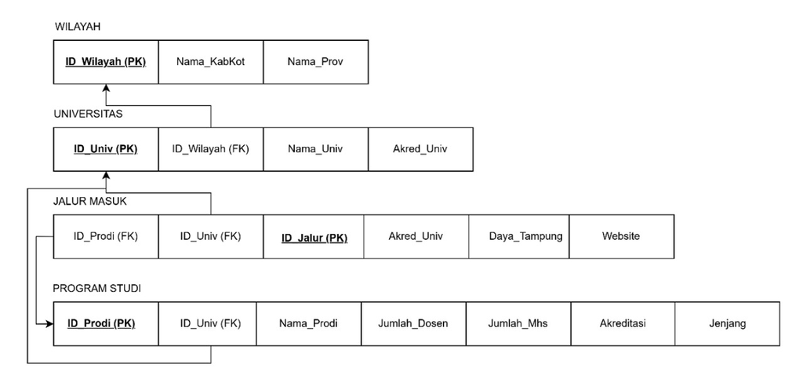

```r
knitr::include_graphics("D:\\Semester 2\\MDS\\Contraints.jpg")
```

Referential Integrity Constraint memastikan bahwa nilai dalam kolom Foreign Key (FK) selalu memiliki pasangan yang valid dalam kolom Primary Key (PK) dari tabel referensinya. Relational Schema dari database yang terdiri dari beberapa tabel dengan atribut-atributnya. Berikut interpretasinya:

1. Tabel WILAYAH  
   Primary Key (PK): **ID_Wilayah**  
   Atribut lain: Nama_KabKot, Nama_Prov
2. Tabel UNIVERSITAS  
   Primary Key (PK): **ID_Univ**  
   Foreign Key (FK): ID_Wilayah (menghubungkan ke WILAYAH)  
   Atribut lain: Nama_Univ, Akred_Univ
3. Tabel JALUR MASUK  
   Primary Key (PK): **ID_Jalur**  
   Foreign Key (FK): ID_Prodi, ID_Univ (menghubungkan ke UNIVERSITAS dan PROGRAM STUDI)  
   Atribut lain: Akred_Univ, Daya_Tampung, Website
4. Tabel PROGRAM STUDI  
   Primary Key (PK): **ID_Prodi**  
   Foreign Key (FK): ID_Univ (menghubungkan ke UNIVERSITAS)  
   Atribut lain: Nama_Prodi, Jumlah_Dosen, Jumlah_Mhs, Akreditasi, Jenjang

# ENTITY RELATIONSHIP DIAGRAM

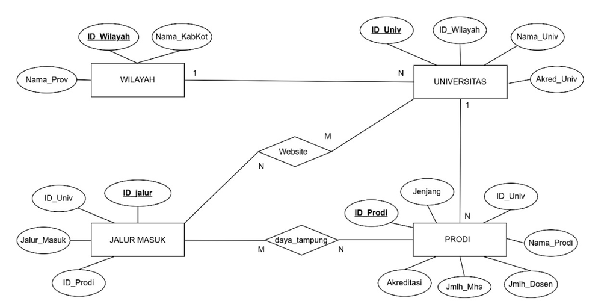

```r
knitr::include_graphics("D:\\Semester 2\\MDS\\ERD.jpg")
```

Entity Relationship Diagram (ERD) yang menjelaskan hubungan antar entitas dalam sistem. Berikut interpretasinya:  
1. Entitas WILAYAH  
Hubungan:  
One to Many (1:N) dengan UNIVERSITAS, artinya **satu wilayah memiliki banyak universitas**.  
2. Entitas UNIVERSITAS  
Hubungan:  
One to Many (1:N) dengan PRODI, artinya **satu universitas memiliki banyak program studi**.  
Many to Many (N:M) dengan JALUR MASUK dan atribut “website” menjadi Relation Entity, artinya **satu universitas memiliki beberapa jalur masuk, dan satu jalur masuk bisa digunakan oleh beberapa universitas**.  
3. Entitas PRODI  
Hubungan:  
One to Many (1:N) dengan UNIVERSITAS, artinya **banyak program studi berada di satu universitas**.  
Many to Many (N:M) dengan JALUR MASUK dan “daya tampung” menjadi Relation Entity, artinya **banyak program studi bisa memiliki banyak jalur masuk**.